# NYPD

T. Parris

2024-04-25

# Introduction

This R Markdown document describes and imports the NYPD project dataset in a reproducible manner.

## Description

List of every shooting incident that occurred in NYC going back to 2006 through the end of the previous calendar year.

This is a breakdown of every shooting incident that occurred in NYC going back to 2006 through the end of the previous calendar year. This data is manually extracted every quarter and reviewed by the Office of Management Analysis and Planning before being posted on the NYPD website. Each record represents a shooting incident in NYC and includes information about the event, the location and time of occurrence. In addition, information related to suspect and victim demographics is also included. This data can be used by the public to explore the nature of shooting/criminal activity.

## Dataset Information

- Dataset Name: NYDP Shooting Incident Data (Historic)
- Source: “https://data.cityofnewyork.us/api/views/833y-fsy8/rows.csv?accessType=DOWNLOAD”
- Format: CSV

## Load necessary Libraries

```r
library(lubridate)
library(tidyverse)
library(dplyr)
```

## Import Dataset

```r
# URL of the dataset
url <- "https://data.cityofnewyork.us/api/views/833y-fsy8/rows.csv?accessType=DOWNLOAD"

# Import the dataset
df_incident <- read_csv(url)
# Display the first few rows of the dataset
head(df_incident)
```

```
## # A tibble: 6 × 21
##   INCIDENT_KEY OCCUR_DATE OCCUR_TIME BORO      LOC_OF_OCCUR_DESC PRECINCT
##          <dbl> <chr>      <time>     <chr>     <chr>                <dbl>
## 1    244608249 05/05/2022 00:10      MANHATTAN INSIDE                  14
## 2    247542571 07/04/2022 22:20      BRONX     OUTSIDE                 48
## 3     84967535 05/27/2012 19:35      QUEENS    <NA>                   103
## 4    202853370 09/24/2019 21:00      BRONX     <NA>                    42
## 5     27078636 02/25/2007 21:00      BROOKLYN  <NA>                    83
## 6    230311078 07/01/2021 23:07      MANHATTAN <NA>                    23
## # ℹ 15 more variables: JURISDICTION_CODE <dbl>, LOC_CLASSFCTN_DESC <chr>,
## #   LOCATION_DESC <chr>, STATISTICAL_MURDER_FLAG <lgl>, PERP_AGE_GROUP <chr>,
## #   PERP_SEX <chr>, PERP_RACE <chr>, VIC_AGE_GROUP <chr>, VIC_SEX <chr>,
## #   VIC_RACE <chr>, X_COORD_CD <dbl>, Y_COORD_CD <dbl>, Latitude <dbl>,
## #   Longitude <dbl>, Lon_Lat <chr>
```

## Tidy and Transform Data

```r
# Clean up unnecessary columns
df_clean <- df_incident %>% select(INCIDENT_KEY,
                   OCCUR_DATE,
                   OCCUR_TIME,
                   BORO,
                   STATISTICAL_MURDER_FLAG,
                   LOC_OF_OCCUR_DESC,
                   PERP_AGE_GROUP,
                   PERP_SEX,
                   PERP_RACE,
                   VIC_AGE_GROUP,
                   VIC_SEX,
                   VIC_RACE,
                   Latitude,
                   Longitude)

# Convert date variable to Date type
df_clean$OCCUR_DATE <- as.Date(df_clean$OCCUR_DATE, format = "%m/%d/%Y")

# Handle missing values

# Replace values not within specified age ranges with "Unknown"
df_clean <- df_clean %>%
  mutate(PERP_AGE_GROUP = case_when(
    is.na(PERP_AGE_GROUP) ~ "Unknown",  # Handle NA values
    PERP_AGE_GROUP %in% c("<18", "18-24", "25-44", "45-64", "65+") ~ PERP_AGE_GROUP,  # Keep values within specified age ranges
    TRUE ~ "Unknown"  # Replace other values with "Unknown"
  ))

df_clean <- df_clean %>%
  mutate(VIC_AGE_GROUP = case_when(
    is.na(VIC_AGE_GROUP) ~ "Unknown",  # Handle NA values
    VIC_AGE_GROUP %in% c("<18", "18-24", "25-44", "45-64", "65+") ~ VIC_AGE_GROUP,  # Keep values within specified age ranges
    TRUE ~ "Unknown"  # Replace other values with "Unknown"
  ))

# Replace missing, specific values, and "UNKNOWN" in PERP_SEX and PERP_RACE
df_clean$PERP_SEX <- ifelse(is.na(df_clean$PERP_SEX) | df_clean$PERP_SEX == "(null)" | df_clean$PERP_SEX == "UNKNOWN", "Unknown", df_clean$PERP_SEX)
df_clean$PERP_RACE <- ifelse(is.na(df_clean$PERP_RACE) | df_clean$PERP_RACE == "(null)" | df_clean$PERP_RACE == "(Other)" | df_clean$PERP_RACE == "UNKNOWN", "Unknown", df_clean$PERP_RACE)

# Replace missing, specific values, and "UNKNOWN" in VIC_SEX and VIC_RACE
df_clean$VIC_SEX <- ifelse(is.na(df_clean$VIC_SEX) | df_clean$VIC_SEX == "(null)" | df_clean$VIC_SEX == "UNKNOWN", "Unknown", df_clean$VIC_SEX)
df_clean$VIC_RACE <- ifelse(is.na(df_clean$VIC_RACE) | df_clean$VIC_RACE == "(null)" | df_clean$VIC_RACE == "(Other)" | df_clean$VIC_RACE == "UNKNOWN", "Unknown", df_clean$VIC_RACE)

# Convert relevant variables to factor type
df_clean <- df_clean %>%
  mutate_at(vars(STATISTICAL_MURDER_FLAG, PERP_AGE_GROUP, PERP_SEX, PERP_RACE, BORO,
                 VIC_AGE_GROUP, VIC_SEX, VIC_RACE), as.factor)

# Display summary statistics
summary(df_clean)
```

```
##   INCIDENT_KEY         OCCUR_DATE          OCCUR_TIME
##  Min.   :  9953245   Min.   :2006-01-01   Length:28562
##  1st Qu.: 65439914   1st Qu.:2009-09-04   Class1:hms
##  Median : 92711254   Median :2013-09-20   Class2:difftime
##  Mean   :127405824   Mean   :2014-06-07   Mode  :numeric
##  3rd Qu.:203131993   3rd Qu.:2019-09-29
##  Max.   :279758069   Max.   :2023-12-29
##
##             BORO       STATISTICAL_MURDER_FLAG LOC_OF_OCCUR_DESC
##  BRONX        : 8376   FALSE:23036             Length:28562
##  BROOKLYN     :11346   TRUE : 5526             Class :character
##  MANHATTAN    : 3762                           Mode  :character
##  QUEENS       : 4271
##  STATEN ISLAND:  807
##
##
##  PERP_AGE_GROUP     PERP_SEX                              PERP_RACE
##  <18    : 1682   F      :  444   AMERICAN INDIAN/ALASKAN NATIVE:    2
##  18-24  : 6438   M      :16168   ASIAN / PACIFIC ISLANDER      :  169
##  25-44  : 6041   U      : 1499   BLACK                         :11903
##  45-64  :  699   Unknown:10451   BLACK HISPANIC                : 1392
##  65+    :   65                   Unknown                       :12288
##  Unknown:13637                   WHITE                         :  298
##                                  WHITE HISPANIC                : 2510
##  VIC_AGE_GROUP   VIC_SEX                             VIC_RACE
##  <18    : 2954   F: 2760   AMERICAN INDIAN/ALASKAN NATIVE:   11
##  18-24  :10384   M:25790   ASIAN / PACIFIC ISLANDER      :  440
##  25-44  :12973   U:   12   BLACK                         :20235
##  45-64  : 1981             BLACK HISPANIC                : 2795
##  65+    :  205             Unknown                       :   70
##  Unknown:   65             WHITE                         :  728
##                            WHITE HISPANIC                : 4283
##     Latitude       Longitude
##  Min.   :40.51   Min.   :-74.25
##  1st Qu.:40.67   1st Qu.:-73.94
##  Median :40.70   Median :-73.92
##  Mean   :40.74   Mean   :-73.91
##  3rd Qu.:40.82   3rd Qu.:-73.88
##  Max.   :40.91   Max.   :-73.70
##  NA's   :59      NA's   :59
```

## Data Visualizations and Analysis

### Data Visualization 1

**- Which Borough in New York City had the most Incidents?**

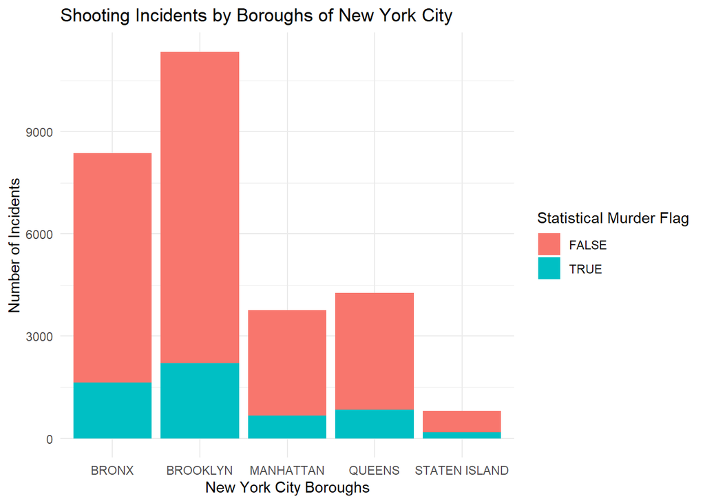

```r
g <- ggplot(df_clean, aes(x = BORO, fill = STATISTICAL_MURDER_FLAG)) +
  geom_bar() +
  labs(title = "Shooting Incidents by Boroughs of New York City",
       x = "New York City Boroughs",
       y = "Number of Incidents",
       fill = "Statistical Murder Flag") +
  theme_minimal()

g
```

Brooklyn leads in both the total number of incidents and murder cases, followed by the Bronx and Queens in succession, mirroring the ranking of incidents.

### Data Visualization 2

**- Which year had the most Incidents in New York City?**

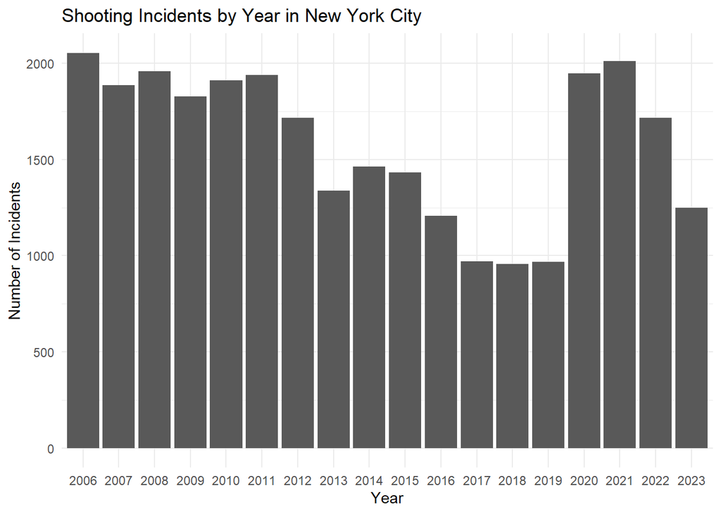

```r
# Extract year from OCCUR_DATE
df_clean <- df_clean %>%
  mutate(OCCUR_YEAR = format(as.Date(OCCUR_DATE), "%Y"))

# Create the plot
g <- ggplot(df_clean, aes(x = OCCUR_YEAR)) +
  geom_bar() +
  labs(title = "Shooting Incidents by Year in New York City",
       x = "Year",
       y = "Number of Incidents") +
  theme_minimal()
g
```

The year with the most incidents was 2006, followed by a gradual decline in the number of incidents until 2020, where there was a notable spike. This increase in incidents during 2020 could be attributed to various factors, including the impact of the COVID-19 pandemic and the heightened socio-political atmosphere surrounding the US elections.

### Data Modelling

**- Predict the Number of Incidents for 2024.**

```r
# Convert OCCUR_YEAR to numeric
df_clean <- df_clean %>%
  mutate(OCCUR_YEAR = as.numeric(OCCUR_YEAR))

# Assuming df_clean is your main dataset
pred_data <- df_clean %>%
  filter(OCCUR_YEAR >= 2020) %>%
  group_by(OCCUR_YEAR) %>%
  summarise(total = n())

# Fit linear regression model
model <- lm(total ~ OCCUR_YEAR, data = pred_data)

# Create new data for prediction
newdata <- tibble(OCCUR_YEAR = c(2024))

# Predict the number of shooting incidents for 2024
predicted_2024 <- predict(model, newdata = newdata)
predicted_2024
```

```
##    1
## 1134
```

The number of incidents predicted for 2024 is 1134.

## Identify Bias

This report used data collected from the City of New York’s open access database, but it’s important to acknowledge any inherent biases within its collection process conducted by the New York Police Department. These could result from variations in reporting practices across areas leading to underreporting or overreporting incidents; external factors like socioeconomic disparities and regional demographics may skew data collection results as well. Therefore, when drawing any conclusions based on these numbers it would be prudent to carefully consider any potential biases when drawing any conclusions derived from them.

Furthermore, it’s notable that there was a spike in incidents during 2020, coinciding with significant events such as a presidential election and the onset of the COVID-19 pandemic. These external factors may have influenced behavioral patterns and reporting practices, contributing to the observed increase in incidents during that period. Hence, it’s crucial to contextualize the data within the broader socio-political and environmental landscape to derive meaningful insights.

## Conclusion

The Borough with the most incidents in New York City is Brooklyn.